# Checkpoint2 AD1 - Análise dos gastos dos deputados federais

8 de julho de 2016

# Distribuição da quantidade de gastos

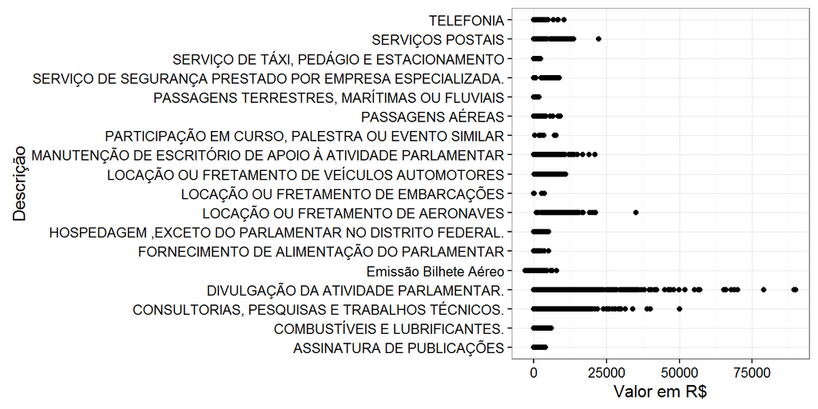

# Total gasto por tipo de gasto

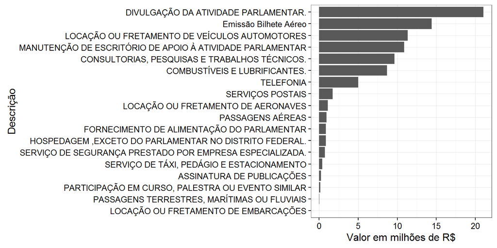

# Desvio padrão dos gastos

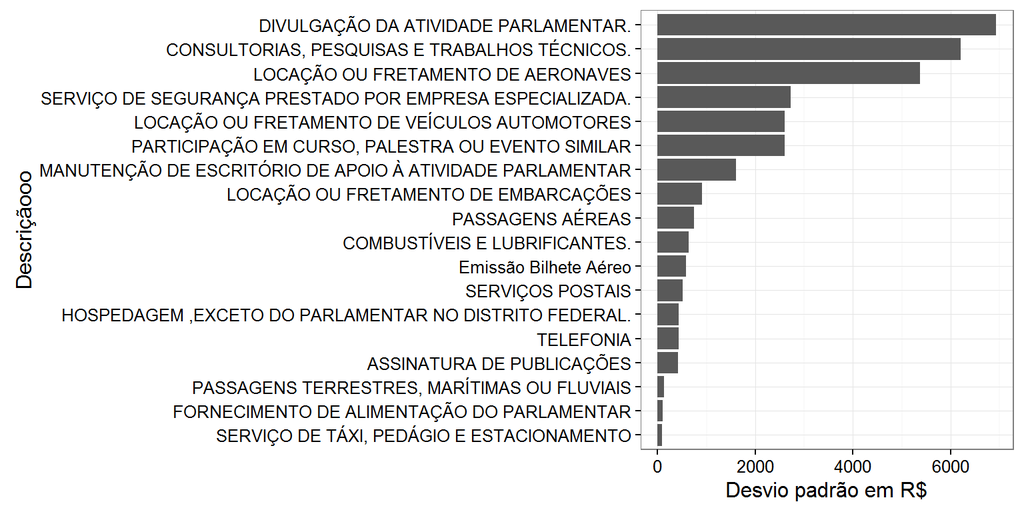

# Total gasto por partido

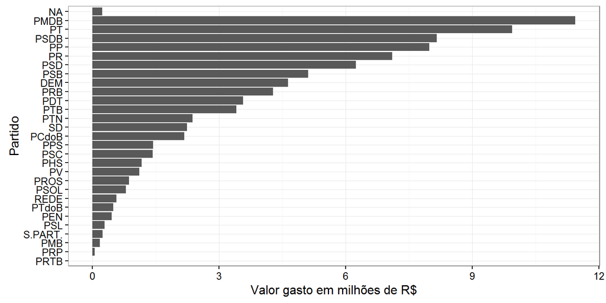

# Número de deputados por partidos

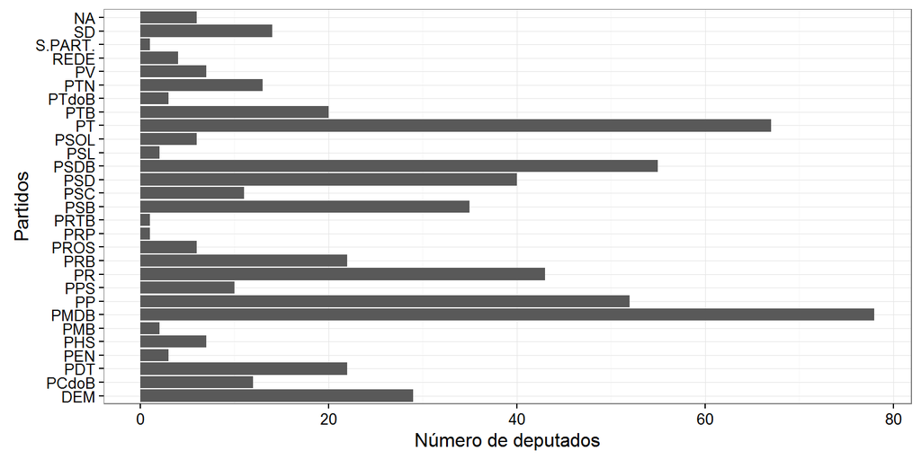

# Gastos dos deputados paraibanos

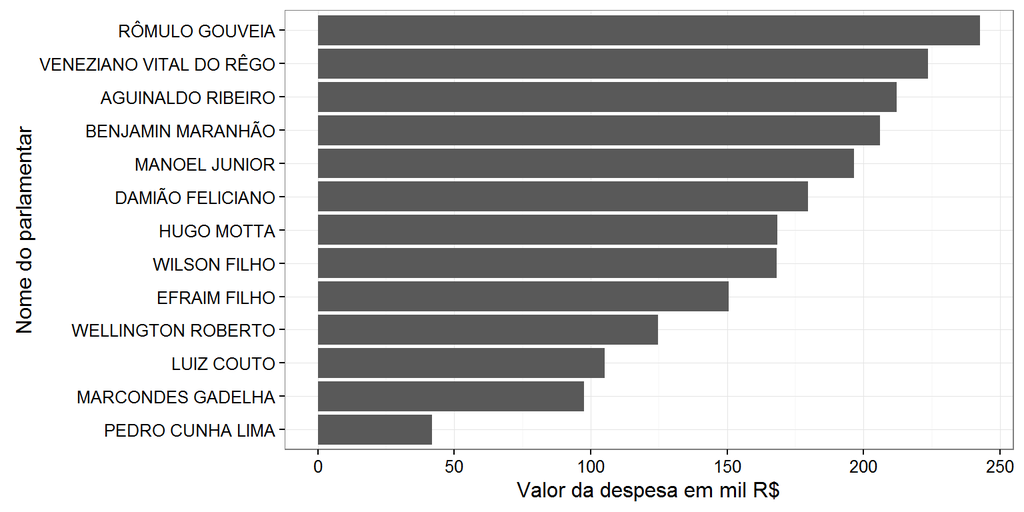

# Gastos por partido na PB

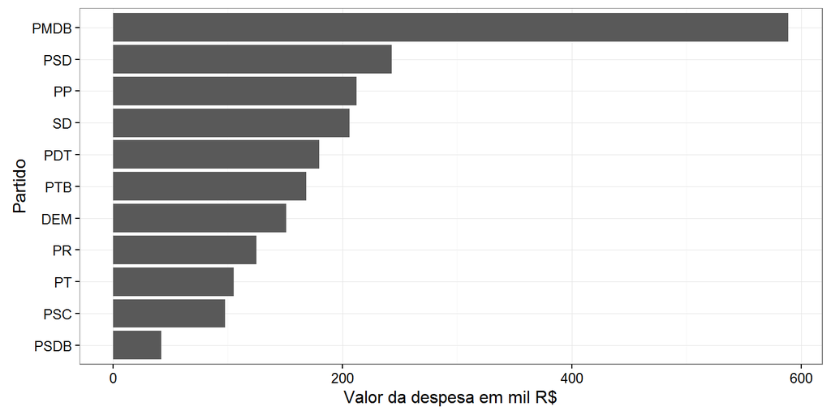

# Número de deputados por partido na PB

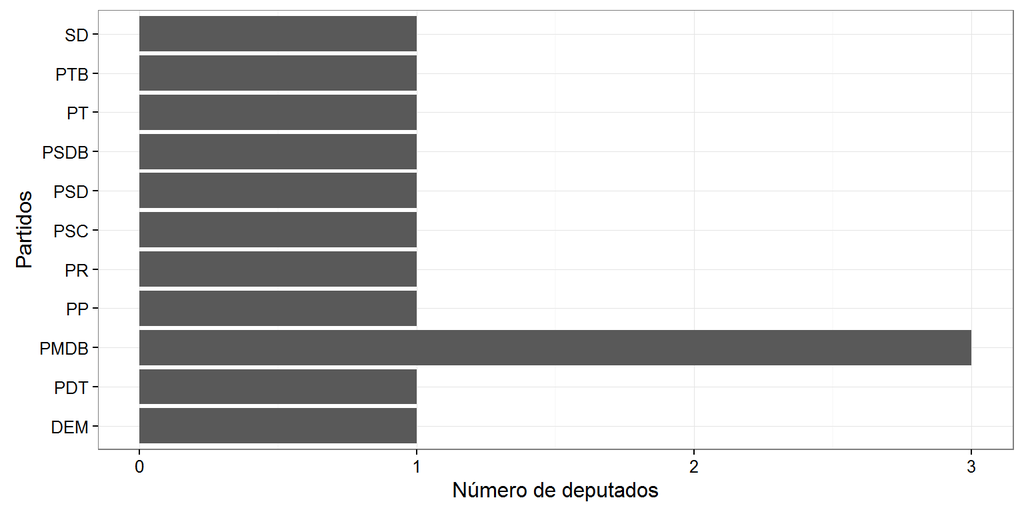

# Descrição dos gastos dos deputados da PB

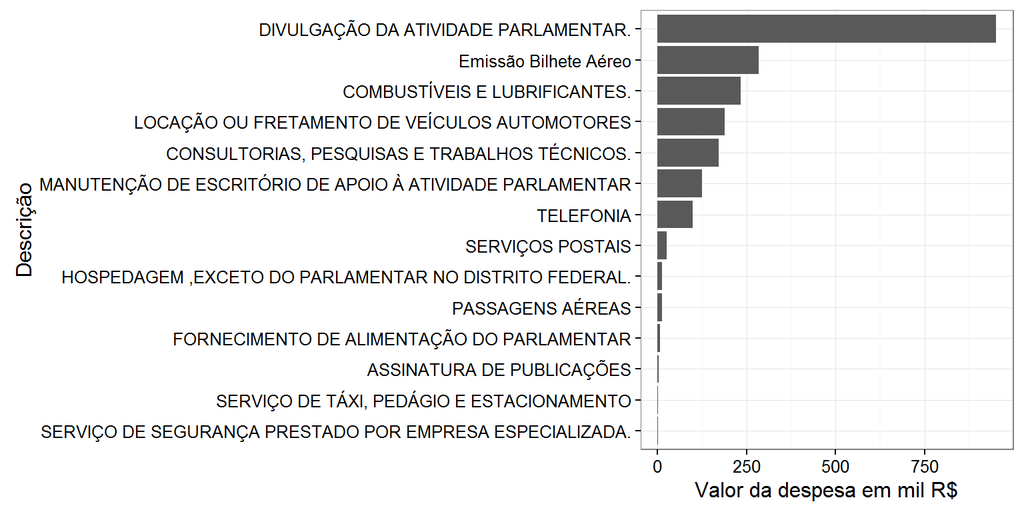

# Relatório:

## Sobre os políticos da PB (foco):

#### - Os maiores gastos são com a divulgação da atividade parlamentar

#### - Observando o número de deputados por partido e seus respectivos gastos , vemos que o PSD é o partido que mais tem despesa. E o partido com menor despesa é o PSDB

#### - Há uma grande variância nos gastos dos deputados, chegando um a gastar 5x mais que o outro, não existindo uma centralidade

### O que surpreendeu nos dados:

#### - Apenas Luiz Couto e Agnaldo Ribeiro assinam publicações

#### - Apenas Rômulo Gouveia tem gastos com serviço de segurança prestado por empresa privada

### Como lidar com esse dados:

#### - Procurar saber que tipo de publicações são essas e porque os demais não tem nenhuma assinatura

#### - Já que Rômulo Gouveia é o único a contratar serviços de segurança, procurar saber se ele já sofreu ameaça de morte, por exemplo.

## Sobre os políticos no Brasil:

#### - Os maiores gastos também são com a divulgação da atividade parlamentar

#### - A maior diferença de gastos de um mesmo tipo, é com a divulgação da atividade parlamentar

### O que surpreendeu nos dados:

#### - Existem mais deputados registrados do que os 513 ativos na câmara

### Como lidar com esse dados:

#### - A Lei Complementar nº 78, de 30 de dezembro de 1993, estabelece que o número de Deputados não pode ultrapassar quinhentos e treze. Apesar de não estarem ativos na Câmara, ainda sim eles geram despesas. Dependendo do tipo de busca a ser realizada nos dados, terá que se tirar os deputados em questão.